# NVIDIA Investment Thesis

In this notebook, we will be performing a quantitative analysis on the prospects of investing into NVIDIA stocks on September 15, 2023. We will primarily be analyzing the fundamental statistics into the company along with a minimal amount of technical analysis. Initially, we will be looking at the company's multiples for their P/E, P/S, and P/B by obtaining data from the Yahoo Finance API. Using this data, we will be performing exploratory data analysis to find descriptive statistics and visualize the information.

In the next stage, we will be performing feature engineering by selecting features that will be used to create and validate several different models. We will be calculating features including the 50 day moving average, the 200 day moving average, as well as other technical indicators such as RSI, MACD, and ROC.

Finally, we will be training several machine learning models as well as a neural network to predict prices. The model algorithms we will be using is linear regression, k nearest neighbors, decision trees, and random forests. Finally, using these predictive algorithms, we will provide a recommendation on the best approach to investing in NVIDIA.

```python
import pandas as pd
import numpy as np
import yfinance as yf
```

```python
nvda_prices = yf.download('NVDA', period='max')
nvda_prices.head()
```

```
[*********************100%%**********************]  1 of 1 completed
```

| Date | Open | High | Low | Close | Adj Close | Volume |
| --- | --- | --- | --- | --- | --- | --- |
| 1999-01-22 | 0.437500 | 0.488281 | 0.388021 | 0.410156 | 0.376288 | 271468800 |
| 1999-01-25 | 0.442708 | 0.458333 | 0.410156 | 0.453125 | 0.415709 | 51048000 |
| 1999-01-26 | 0.458333 | 0.467448 | 0.411458 | 0.417969 | 0.383456 | 34320000 |
| 1999-01-27 | 0.419271 | 0.429688 | 0.395833 | 0.416667 | 0.382261 | 24436800 |
| 1999-01-28 | 0.416667 | 0.419271 | 0.412760 | 0.415365 | 0.381067 | 22752000 |

## Exploratory Data Analysis

- Derive insights about NVDA's stock.
- Find relationships between NVDA and microeconomic/macroeconomic factors.

```python
# Import relevant libraries
import matplotlib.pyplot as plt
import seaborn as sns
```

```python
# Calculate the Multiples
nvda = yf.Ticker("NVDA")

# We are getting the most recent quarterly features
financials = nvda.quarterly_financials.transpose()
pd.set_option('display.max_columns', None)

print(financials.columns)
financials
```

```
Index(['Tax Effect Of Unusual Items', 'Tax Rate For Calcs',
       'Normalized EBITDA', 'Total Unusual Items',
       'Total Unusual Items Excluding Goodwill',
       'Net Income From Continuing Operation Net Minority Interest',
       'Reconciled Depreciation', 'Reconciled Cost Of Revenue', 'EBITDA',
       'EBIT', 'Net Interest Income', 'Interest Expense', 'Interest Income',
       'Normalized Income',
       'Net Income From Continuing And Discontinued Operation',
       'Total Expenses', 'Total Operating Income As Reported',
       'Diluted Average Shares', 'Basic Average Shares', 'Diluted EPS',
       'Basic EPS', 'Diluted NI Availto Com Stockholders',
       'Net Income Common Stockholders', 'Net Income',
       'Net Income Including Noncontrolling Interests',
       'Net Income Continuous Operations', 'Tax Provision', 'Pretax Income',
       'Other Income Expense', 'Other Non Operating Income Expenses',
       'Special Income Charges', 'Restructuring And Mergern Acquisition',
       'Net Non Operating Interest Income Expense',
       'Interest Expense Non Operating', 'Interest Income Non Operating',
       'Operating Income', 'Operating Expense', 'Research And Development',
       'Selling General And Administration', 'Gross Profit', 'Cost Of Revenue',
       'Total Revenue', 'Operating Revenue'],
      dtype='object')
```

|  | Tax Effect Of Unusual Items | Tax Rate For Calcs | Normalized EBITDA | Total Unusual Items | Total Unusual Items Excluding Goodwill | Net Income From Continuing Operation Net Minority Interest | Reconciled Depreciation | Reconciled Cost Of Revenue | EBITDA | EBIT | Net Interest Income | Interest Expense | Interest Income | Normalized Income | Net Income From Continuing And Discontinued Operation | Total Expenses | Total Operating Income As Reported | Diluted Average Shares | Basic Average Shares | Diluted EPS | Basic EPS | Diluted NI Availto Com Stockholders | Net Income Common Stockholders | Net Income | Net Income Including Noncontrolling Interests | Net Income Continuous Operations | Tax Provision | Pretax Income | Other Income Expense | … |
| --- | --- | --- | --- | --- | --- | --- | --- | --- | --- | --- | --- | --- | --- | --- | --- | --- | --- | --- | --- | --- | --- | --- | --- | --- | --- | --- | --- | --- | --- | --- |
| 2023-07-31 | 0.0 | 0.113594 | 7411000000.0 | 0.0 | 0.0 | 6188000000.0 | 365000000.0 | 4045000000.0 | 7411000000.0 | 7046000000.0 | 122000000.0 | 65000000.0 | 187000000.0 | 6188000000.0 | 6188000000.0 | 6707000000.0 | 6800000000.0 | 2499000000.0 | 2473000000.0 | 2.48 | 2.5 | 6188000000.0 | 6188000000.0 | 6188000000.0 | 6188000000.0 | 6188000000.0 | 793000000.0 | 6981000000.0 | 59000000.0 | … |
| 2023-04-30 | 0.0 | 0.075 | 2659000000.0 | 0.0 | 0.0 | 2043000000.0 | 384000000.0 | 2544000000.0 | 2659000000.0 | 2275000000.0 | 84000000.0 | 66000000.0 | 150000000.0 | 2043000000.0 | 2043000000.0 | 5052000000.0 | 2140000000.0 | 2490000000.0 | 2470000000.0 | 0.82 | 0.83 | 2043000000.0 | 2043000000.0 | 2043000000.0 | 2043000000.0 | 2043000000.0 | 166000000.0 | 2209000000.0 | -15000000.0 | … |
| 2023-01-31 | 0.0 | 0.4 | 1780000000.0 | 0.0 | 0.0 | 1414000000.0 | 426000000.0 | 2218000000.0 | 1780000000.0 | 1354000000.0 | 50000000.0 | 65000000.0 | 115000000.0 | 1414000000.0 | 1414000000.0 | 4794000000.0 | 1257000000.0 | 2477000000.0 | 2464000000.0 | 0.57 | 0.57 | 1414000000.0 | 1414000000.0 | 1414000000.0 | 1414000000.0 | 1414000000.0 | -125000000.0 | 1289000000.0 | -18000000.0 | … |
| 2022-10-31 | 0.0 | 0.109 | 1084000000.0 | 0.0 | 0.0 | 680000000.0 | 406000000.0 | 2754000000.0 | 1084000000.0 | 678000000.0 | 23000000.0 | 65000000.0 | 88000000.0 | 680000000.0 | 680000000.0 | 5330000000.0 | 601000000.0 | 2499000000.0 | 2483000000.0 | 0.27 | 0.27 | 680000000.0 | 680000000.0 | 680000000.0 | 680000000.0 | 680000000.0 | -67000000.0 | 613000000.0 | -11000000.0 | … |
| 2022-07-31 | 0.0 | 0.4 | 918000000.0 | 0.0 | 0.0 | 656000000.0 | 378000000.0 | 3789000000.0 | 918000000.0 | 540000000.0 | -19000000.0 | 65000000.0 | 46000000.0 | 656000000.0 | 656000000.0 | 6205000000.0 | 499000000.0 | 2516000000.0 | 2495000000.0 | 0.26 | 0.26 | 656000000.0 | 656000000.0 | 656000000.0 | 656000000.0 | 656000000.0 | -181000000.0 | 475000000.0 | -5000000.0 | … |

```python
# Get the recent quarterly balance sheet
balance_sheet = nvda.quarterly_balance_sheet.transpose()

print(balance_sheet.columns)
balance_sheet
```

```
Index(['Ordinary Shares Number', 'Share Issued', 'Net Debt', 'Total Debt',
       'Tangible Book Value', 'Invested Capital', 'Working Capital',
       'Net Tangible Assets', 'Capital Lease Obligations',
       'Common Stock Equity', 'Total Capitalization',
       'Total Equity Gross Minority Interest', 'Stockholders Equity',
       'Gains Losses Not Affecting Retained Earnings',
       'Other Equity Adjustments', 'Retained Earnings',
       'Additional Paid In Capital', 'Capital Stock', 'Common Stock',
       'Preferred Stock', 'Total Liabilities Net Minority Interest',
       'Total Non Current Liabilities Net Minority Interest',
       'Other Non Current Liabilities', 'Tradeand Other Payables Non Current',
       'Non Current Deferred Liabilities', 'Non Current Deferred Revenue',
       'Non Current Deferred Taxes Liabilities',
       'Long Term Debt And Capital Lease Obligation',
       'Long Term Capital Lease Obligation', 'Long Term Debt',
       'Current Liabilities', 'Other Current Liabilities',
       'Current Deferred Liabilities', 'Current Deferred Revenue',
       'Current Debt And Capital Lease Obligation',
       'Current Capital Lease Obligation', 'Current Debt',
       'Other Current Borrowings', 'Current Provisions',
       'Payables And Accrued Expenses', 'Current Accrued Expenses', 'Payables',
       'Total Tax Payable', 'Accounts Payable', 'Total Assets',
       'Total Non Current Assets', 'Other Non Current Assets',
       'Non Current Prepaid Assets', 'Non Current Deferred Assets',
       'Non Current Deferred Taxes Assets', 'Investments And Advances',
       'Other Investments', 'Goodwill And Other Intangible Assets',
       'Other Intangible Assets', 'Goodwill', 'Net PPE',
       'Accumulated Depreciation', 'Gross PPE', 'Construction In Progress',
       'Other Properties', 'Machinery Furniture Equipment',
       'Buildings And Improvements', 'Land And Improvements', 'Properties',
       'Current Assets', 'Other Current Assets', 'Prepaid Assets', 'Inventory',
       'Finished Goods', 'Work In Process', 'Raw Materials', 'Receivables',
       'Accounts Receivable',
       'Cash Cash Equivalents And Short Term Investments',
       'Other Short Term Investments', 'Cash And Cash Equivalents'],
      dtype='object')
```

|  | Ordinary Shares Number | Share Issued | Net Debt | Total Debt | Tangible Book Value | Invested Capital | Working Capital | Net Tangible Assets | Capital Lease Obligations | Common Stock Equity | Total Capitalization | Total Equity Gross Minority Interest | Stockholders Equity | Gains Losses Not Affecting Retained Earnings | Other Equity Adjustments | Retained Earnings | Additional Paid In Capital | Capital Stock | Common Stock | Preferred Stock | Total Liabilities Net Minority Interest | Total Non Current Liabilities Net Minority Interest | Other Non Current Liabilities | Tradeand Other Payables Non Current | Non Current Deferred Liabilities | Non Current Deferred Revenue | Non Current Deferred Taxes Liabilities | Long Term Debt And Capital Lease Obligation | Long Term Capital Lease Obligation | … |
| --- | --- | --- | --- | --- | --- | --- | --- | --- | --- | --- | --- | --- | --- | --- | --- | --- | --- | --- | --- | --- | --- | --- | --- | --- | --- | --- | --- | --- | --- | --- |
| 2023-07-31 | 2469000000.0 | 2469000000.0 | 9705000000.0 | 10746000000.0 | 21676000000.0 | 9705000000.0 | 18463000000.0 | 21676000000.0 | 1041000000.0 | 27501000000.0 | 35957000000.0 | 27501000000.0 | 27501000000.0 | -51000000.0 | -51000000.0 | 14921000000.0 | 12629000000.0 | 2000000.0 | 2000000.0 | 0.0 | 22054000000.0 | 11720000000.0 | 2223000000.0 | 1477000000.0 | 681000000.0 | 308000000.0 | 373000000.0 | 9497000000.0 | 1041000000.0 | … |
| 2023-04-30 | 2473000000.0 | 2473000000.0 | 10954000000.0 | 11893000000.0 | 18549000000.0 | 10954000000.0 | 17623000000.0 | 18549000000.0 | 939000000.0 | 24520000000.0 | 34224000000.0 | 24520000000.0 | 24520000000.0 | -50000000.0 | -50000000.0 | 12115000000.0 | 12453000000.0 | 2000000.0 | 2000000.0 | 0.0 | 19940000000.0 | 12680000000.0 | 2037000000.0 | 1455000000.0 | 520000000.0 | 230000000.0 | 290000000.0 | 10643000000.0 | 939000000.0 | … |
| 2023-01-31 | 2466136572.0 | 2466136572.0 | 10953000000.0 | 11855000000.0 | 16053000000.0 | 10953000000.0 | 16510000000.0 | 16053000000.0 | 902000000.0 | 22101000000.0 | 31804000000.0 | 22101000000.0 | 22101000000.0 | -43000000.0 | -43000000.0 | 10171000000.0 | 11971000000.0 | 2000000.0 | 2000000.0 | 0.0 | 19081000000.0 | 12518000000.0 | 1913000000.0 | 1385000000.0 | 465000000.0 | 218000000.0 | 247000000.0 | 10605000000.0 | 902000000.0 | … |
| 2022-10-31 | 2468000000.0 | 2468000000.0 | 10950000000.0 | 11748000000.0 | 15127000000.0 | 10950000000.0 | 16368000000.0 | 15127000000.0 | 798000000.0 | 21349000000.0 | 31050000000.0 | 21349000000.0 | 21349000000.0 | -123000000.0 | -123000000.0 | 9905000000.0 | 11565000000.0 | 2000000.0 | 2000000.0 | 0.0 | 19139000000.0 | 12284000000.0 | 1785000000.0 | 1057000000.0 | 459000000.0 | 213000000.0 | 246000000.0 | 10499000000.0 | 798000000.0 | … |
| 2022-07-31 | 2489000000.0 | 2489000000.0 | 10949000000.0 | 11692000000.0 | 17443000000.0 | 10949000000.0 | 19845000000.0 | 17443000000.0 | 743000000.0 | 23851000000.0 | 33551000000.0 | 23851000000.0 | 23851000000.0 | -90000000.0 | -90000000.0 | 12971000000.0 | 10968000000.0 | 2000000.0 | 2000000.0 | 0.0 | 19625000000.0 | 12052000000.0 | 1609000000.0 | 1022000000.0 | 453000000.0 | 201000000.0 | 252000000.0 | 10443000000.0 | 743000000.0 | … |

```python
# Current stock price
current_price = nvda.info['currentPrice']
eps = financials['Diluted EPS'].iloc[0]

# Calculate P/E multiple
pe = current_price / eps

revenue_per_share = financials['Total Revenue'].iloc[0] / nvda.info['sharesOutstanding']

# Calculate P/S multiple
ps = current_price / revenue_per_share
```

```python
book_value_per_share = balance_sheet["Stockholders Equity"].iloc[0] / nvda.info['sharesOutstanding']

# Calculate P/B multiple
pb = current_price / book_value_per_share
```

```python
print("Price to Earnings:", pe)
print("Price to Revenue:", ps)
print("Price to Book:", pb)
```

```
Price to Earnings: 177.01612903225808
Price to Revenue: 80.27911869341823
Price to Book: 39.42875008879677
```

# Notes on the Multiples

- Price to Earnings Ratio (P/E): Stock price per share
  - A P/E of 177 is insanely high, even for tech companies. This is because the market has very high expectations for NVIDIA. It is placed in the best position to take advantage of the AI boom. However, this multiple is too high.
- Price to Sales Ratio (P/S): Stock price to revenue per share
  - NVIDIA is a growth oriented company but a P/S of 80 is still very high. The market believes that there will be high growth in revenue for the company.
- Price to Book Ratio (P/B): Stock price to book value
  - A high P/B means that investors highly value the intangible assets of the company. This is likely the value of the brand itself as well as the high talent and capabilities of the company.

For the next part, we will be visualizing the data in the initial dataframe.

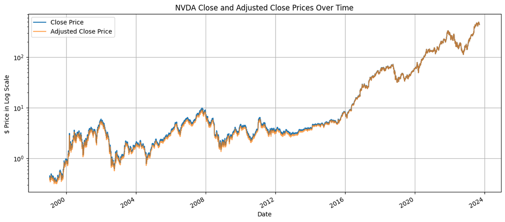

```python
# Close and Adjusted Close Over Time
plt.figure(figsize=(14,6))
nvda_prices['Close'].plot(label='Close Price', legend=True)
nvda_prices['Adj Close'].plot(label='Adjusted Close Price', legend=True, alpha=0.7)
plt.title('NVDA Close and Adjusted Close Prices Over Time')
plt.xlabel('Date')
plt.ylabel('$ Price in Log Scale ')
plt.yscale('log')
plt.grid(True)
plt.show()
```

```python
# 50 day moving average
nvda_prices['50_MA'] = nvda_prices['Close'].rolling(window=50).mean()

# 200 day moving average
nvda_prices['200_MA'] = nvda_prices['Close'].rolling(window=200).mean()
```

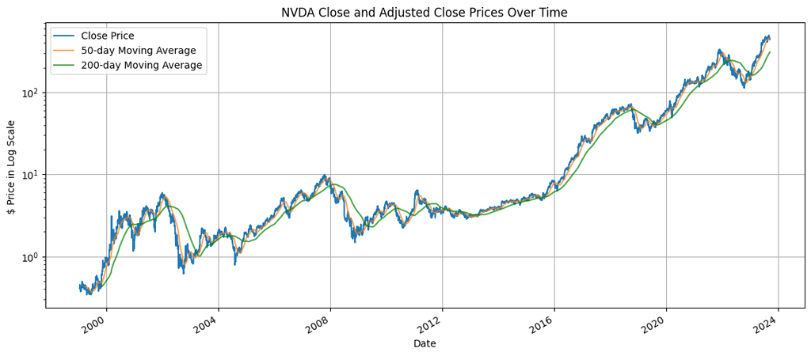

```python
# Close and Adjusted Close Over Time
plt.figure(figsize=(14,6))
nvda_prices['Close'].plot(label='Close Price', legend=True)
nvda_prices['50_MA'].plot(label='50-day Moving Average', legend=True, alpha=0.7)
nvda_prices['200_MA'].plot(label='200-day Moving Average', legend=True, alpha=0.7, color='green')
plt.title('NVDA Close and Adjusted Close Prices Over Time')
plt.xlabel('Date')
plt.ylabel('$ Price in Log Scale ')
plt.yscale('log')
plt.grid(True)
plt.show()
```

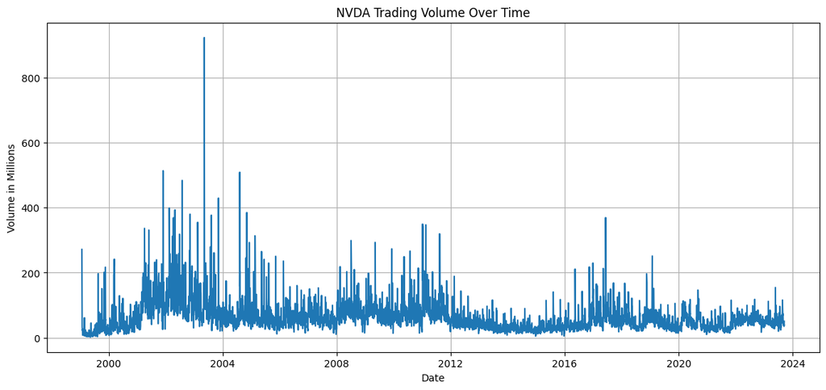

```python
# Visualize the trading volume history
plt.figure(figsize=(14,6))
plt.plot(nvda_prices['Volume'] / 1e6, label='Volume')
plt.title('NVDA Trading Volume Over Time')
plt.xlabel('Date')
plt.ylabel('Volume in Millions')
plt.grid(True)
plt.show()
```

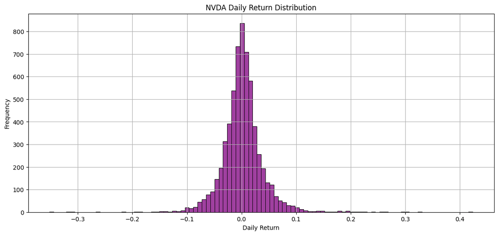

```python
# Calculate the daily returns
# This should follow a normal distributiion
nvda_prices['Daily Return'] = nvda_prices['Close'].pct_change()
plt.figure(figsize=(14,6))
sns.histplot(nvda_prices['Daily Return'].dropna(), bins=100, color='purple')
plt.title('NVDA Daily Return Distribution')
plt.xlabel('Daily Return')
plt.ylabel('Frequency')
plt.grid(True)
plt.show()
```

As expected, the distribution of the daily returns are roughly normally distributed centered at 0.

```python
# We're going to start with some simple descriptive statistics
# to see what data the yfinance api is providing
nvda_prices.describe()
```

|  | Open | High | Low | Close | Adj Close | Volume | 50_MA | 200_MA | Daily Return |
| --- | --- | --- | --- | --- | --- | --- | --- | --- | --- |
| count | 6203.000000 | 6203.000000 | 6203.000000 | 6203.000000 | 6203.000000 | 6.203000e+03 | 6154.000000 | 6004.000000 | 6202.000000 |
| mean | 37.321290 | 38.022332 | 36.592846 | 37.334646 | 37.072215 | 6.117420e+07 | 35.808363 | 32.409452 | 0.001846 |
| std | 76.713672 | 78.151890 | 75.163545 | 76.694985 | 76.705680 | 4.379955e+07 | 71.743430 | 61.118599 | 0.038113 |
| min | 0.348958 | 0.355469 | 0.333333 | 0.341146 | 0.312976 | 1.968000e+06 | 0.366706 | 0.427562 | -0.352335 |
| 25% | 2.695000 | 2.783750 | 2.625000 | 2.702500 | 2.479343 | 3.448680e+07 | 2.704329 | 2.858169 | -0.016307 |
| 50% | 4.410000 | 4.479167 | 4.327500 | 4.407500 | 4.052731 | 5.132640e+07 | 4.339883 | 4.106989 | 0.001015 |
| 75% | 36.160002 | 36.735001 | 35.637501 | 36.167500 | 35.822113 | 7.438140e+07 | 36.473025 | 32.745228 | 0.017980 |
| max | 502.160004 | 502.660004 | 489.579987 | 493.549988 | 493.509338 | 9.230856e+08 | 454.040999 | 308.512600 | 0.424145 |

### Notes on Descriptive Statistics

- Price Movement
  - The range of NVIDIA stocks have a very high range over the years. Throughout it's history, its lowest value is $0.34 and its highest is $493.55. Evidently, NVIDIA has shown tremendous growth.
- Volume
  - The trading volume also has a very high variation with a maximum of 900 million shares a day and a minimum of about 2 million shares a day. The average trading volume is around 61 million shares.
- Daily Return
  - On average, the stock has shown a slightly positive daily return on investment. The highest drop is about 35% and the highest gain is roughly 42%.
- Technical Indicators
  - The moving averagees provides some insight on the short term and long term trends of the stock. It appears that the stock is currently hedged to continue growth with diminishing returns.

## Feature Engineering

- Create relevant features for your models.
- Justify your choice of why these features are important.

The primary features that we are using are the following:

- Moving Averages
  - The 50 and 200 day moving averages are useful for determining the stock's trend. When a stock's current price is above its moving average, it is generally considered an upward trend and vice versa.
- Lagged Close
  - The lagged close price is the closing price of the previous trading day. This is based on the theoretical idea that previous prices can influence the price of the future. However, the importance of this feature is highly debated. As a result, I am only taking the lagged close of the previous day.
- Relative Strength Index (RSI)
  - The RSI is a momentum oscillator that measures the speed of the change of price movements going from 0 to 100. At the moment, I don't have much comprehensive knowledge of its utility but I read that a RSI above 70 means that a stock is overbought and below 30 means it is oversold.
- MACD
  - MACD represents the difference from short term and long term moving averages. To be honest, I don't have a very strong understanding of MACD at the moment but it is a momentum oscillator used to idetify overbought and oversold conditions. A MACD > 0 is considered bullish and MACD < 0 is considered bearish.
- Rate of Change (ROC)
  - Measures the % change in price from the price of a set number of days ago. In our case, we are comparing with 20 days ago.

```python
# We already have calculated the 50 and 200 day moving averages for the visualizations
# However, heres the same code to recalculate it
nvda_prices['50_MA'] = nvda_prices['Close'].rolling(window=50).mean()
nvda_prices['200_MA'] = nvda_prices['Close'].rolling(window=200).mean()

# We are lagging the prices by 1 day
nvda_prices['Lagged_Close'] = nvda_prices['Close'].shift(1)

# RSI Calculations

# First, get the difference
delta = nvda_prices['Close'].diff()
# Separate the gain and losses
gain = (delta.where(delta > 0, 0))
loss = (-delta.where(delta < 0, 0))

# Find the average gain and loss
avg_gain = gain.rolling(window=14).mean()
avg_loss = loss.rolling(window=14).mean()

# RSI is 100 - (100 / (1 + (average gain / average loss)))
# It is calculated as follows
rs = avg_gain / avg_loss
nvda_prices['RSI'] = 100 - (100 / (1 + rs))

# EMA means exponential moving average
short_ema = nvda_prices['Close'].ewm(span=12, adjust=False).mean()
long_ema = nvda_prices['Close'].ewm(span=26, adjust=False).mean()

# We are subtracting the 26 day exponential moving average and 12 day exponential moving average
nvda_prices['MACD'] = short_ema - long_ema

# Rate Of Change (ROC)
nvda_prices['ROC'] = nvda_prices['Close'].pct_change(periods=20)

# Show the most recent data
nvda_prices.tail()
```

| Date | Open | High | Low | Close | Adj Close | Volume | 50_MA | 200_MA | Daily Return | Lagged_Close | RSI | MACD | ROC |
| --- | --- | --- | --- | --- | --- | --- | --- | --- | --- | --- | --- | --- | --- |
| 2023-09-11 | 461.480011 | 461.630005 | 443.119995 | 451.779999 | 451.779999 | 47396600 | 451.900799 | 302.75350 | -0.008646 | 455.720001 | 42.242648 | 5.934964 | 0.105813 |
| 2023-09-12 | 447.380005 | 456.730011 | 445.309998 | 448.700012 | 448.700012 | 34925600 | 452.414399 | 304.19510 | -0.006817 | 451.779999 | 46.214431 | 4.060850 | 0.025530 |
| 2023-09-13 | 446.000000 | 459.299988 | 445.029999 | 454.850006 | 454.850006 | 39835500 | 453.028799 | 305.64340 | 0.013706 | 448.700012 | 41.598848 | 3.036848 | 0.035162 |
| 2023-09-14 | 459.500000 | 459.869995 | 451.309998 | 455.809998 | 455.809998 | 37009700 | 453.681599 | 307.10895 | 0.002111 | 454.850006 | 41.892165 | 2.276540 | 0.048176 |
| 2023-09-15 | 453.410004 | 455.989990 | 438.079987 | 439.000000 | 439.000000 | 50571300 | 454.040999 | 308.51260 | -0.036879 | 455.809998 | 39.710457 | 0.313945 | 0.012828 |

Determine the importance of each feature by using a random forest.

```python
# Used to calculate importance of features
from sklearn.ensemble import RandomForestRegressor
```

```python
nvda_prices_cleaned = nvda_prices.dropna()
nvda_prices_cleaned = nvda_prices_cleaned.drop_duplicates()

features = ['50_MA', '200_MA', 'Lagged_Close', 'RSI', 'MACD', 'ROC']
X = nvda_prices_cleaned[features]
y = nvda_prices_cleaned['Close']

# We can fit the entire dataset because this does not require testing
# Also makes it simpler
random_forest = RandomForestRegressor()
random_forest.fit(X, y)
rf_importances = random_forest.feature_importances_

feature_importances = pd.DataFrame({
    'Feature': X.columns,
    'Random Forest': rf_importances,
})

# Sort by Random Forest to find most important features
feature_importances = feature_importances.sort_values(by='Random Forest', ascending=False)

feature_importances
```

|  | Feature | Random Forest |
| --- | --- | --- |
| 2 | Lagged_Close | 0.361280 |
| 0 | 50_MA | 0.344523 |
| 1 | 200_MA | 0.293502 |
| 3 | RSI | 0.000299 |
| 5 | ROC | 0.000218 |
| 4 | MACD | 0.000178 |

## Predictive Modeling

- Create a model to forecast prices.
- Evaluate your model performance.
- Discuss pros/cons of the models you used.

```python
# Import the relevant libraries
# from sklearn.model_selection import train_test_split
from sklearn.metrics import mean_squared_error, r2_score, mean_absolute_error
from sklearn.linear_model import LinearRegression
from sklearn.neighbors import KNeighborsRegressor
from sklearn.tree import DecisionTreeRegressor

from sklearn.model_selection import TimeSeriesSplit

# For the neural network
from sklearn.preprocessing import MinMaxScaler
from keras.models import Sequential
from keras.layers import Dense, Dropout
```

We are going to be using a few simple predicitve models. Notably, linear regression, decision trees, random forests, and K Nearest Neighbors (KNN). We will be comparing the performances of these models with mean squared error, mean absolute error, and residual squared.

These models are not too complex but they are different approaches to try to model the trend. I belive the a linear regression models is definitely too simple to model the complex trend of the stock price. However, it is worth including as a benchmark.

Also, it is important to note that KNN is very sensitive to feature scales. Without scaling the features, columns with larger values will be weighted more. This is because KNN is calculated using euclidean distances.

```python
tscv = TimeSeriesSplit(n_splits=5)

models = {
    "Linear Regression": LinearRegression(),
    "Decision Tree": DecisionTreeRegressor(),
    "Random Forest": RandomForestRegressor(),
    "k-NN": KNeighborsRegressor(n_neighbors=5)
}
```

```python
# Holds the dataframe for the results of the models
model_results = {}

# Perform this operation for each model
for name, model in models.items():
    mse_scores = []
    mae_scores = []
    r2_scores = []

    # Split with a timeseries split of 5
    for train_index, test_index in tscv.split(X):
        X_train, X_test = X.iloc[train_index], X.iloc[test_index]
        y_train, y_test = y.iloc[train_index], y.iloc[test_index]

        # Fit the model and predict
        model.fit(X_train, y_train)
        predictions = model.predict(X_test)

        mse_scores.append(mean_squared_error(y_test, predictions))
        mae_scores.append(mean_absolute_error(y_test, predictions))
        r2_scores.append(r2_score(y_test, predictions))

    model_results[name] = {
        'Mean MSE': np.mean(mse_scores),
        'Mean MAE': np.mean(mae_scores),
        'R Squared': np.mean(r2_scores)
    }

model_results_df = pd.DataFrame(model_results).transpose()
model_results_df
```

|  | Mean MSE | Mean MAE | R Squared |
| --- | --- | --- | --- |
| Linear Regression | 8.062573 | 1.008883 | 0.994846 |
| Decision Tree | 4744.990368 | 28.153913 | -0.095531 |
| Random Forest | 4746.710367 | 28.141033 | -0.087048 |
| k-NN | 4768.153495 | 28.465877 | -0.130462 |

#### Building the Neural Network

```python
# Separate the features and the label
X = nvda_prices_cleaned.drop('Close', axis=1)
y = nvda_prices_cleaned['Close']

# We need to scale the data so that it is well suited for neural network models
scaler_X, scaler_y = MinMaxScaler(), MinMaxScaler()
X_scaled = scaler_X.fit_transform(X)
y_scaled = scaler_y.fit_transform(y.values.reshape(-1, 1))

# We are using n 80/20 split with 80% training and 20% testing
train_size = int(0.8 * len(X_scaled))
X_train, X_test = X_scaled[:train_size], X_scaled[train_size:]
y_train, y_test = y_scaled[:train_size], y_scaled[train_size:]

# NOTE: It is important to note we cant simply use the traintestsplit function to separate the data
# this is because we are using time series split
```

### Neural Network Architecture

This neural network will be using rectified linear units "relu" for the activation function. It will output a single linear value. I chose the "relu" activation function because it is simply the one I have the best understanding of. I have used a similar architecture in my chess project, however that was a convolutional neural network. I may experiment with different neural network architectures later and compare the results but for the moment I have the best understanding of what's shown below.

Then, we are going to compile the model using the adam optimizer with a loss function of a mean squared error.

```python
# Neural network architecture
model = Sequential()
model.add(Dense(128, input_dim=X_train.shape[1], activation='relu'))
model.add(Dropout(0.2))
model.add(Dense(64, activation='relu'))
model.add(Dropout(0.2))
model.add(Dense(32, activation='relu'))
model.add(Dense(1, activation='linear'))

# Adam optimizer
model.compile(loss='mean_squared_error', optimizer='adam')
```

#### Train the model

We will be training the model for 50 epochs with a batch size of 32. This is pretty standard for many different scenarios of training a neural network.

```python
num_epochs = 50
batch_size = 32

history = model.fit(X_train, y_train, epochs=num_epochs, batch_size=batch_size, validation_data=(X_test, y_test))
```

```python
# Evaluate the model
train_loss = model.evaluate(X_train, y_train, verbose=0)
test_loss = model.evaluate(X_test, y_test, verbose=0)

print("Train Loss:", train_loss)
print("Test Loss:", test_loss)

# You can use the code below if you want to predict with new values
# It is rescaled to normal scale
# predictions = scaler_y.inverse_transform(model.predict(***new features***))
```

```
Train Loss: 2.7348793082637712e-05
Test Loss: 0.009585628286004066
```

## Recommendation

I recommend to avoid buying NVIDIA stocks for the short term. At the moment, the market is incredibly optimistic about the positioning of the company and they stand to be the primary distributor of GPUs for data centers and training artificial intelligence. They have a long and strong history with GPUs which are ideal for the current market hype for deploying and training artificial intelligence models. However, this market hype will introduce several more companies and competition for NVIDIA to try and get their share in the GPU market.

The incredible market optimisism of NVIDIA is seen through the insanely high multiples of their stock P/E, P/S, and P/B. This makes it very susceptible to short-term volatility in the event that the company does not meet these expectations. Furthermore, several large companies that require computation intensive operations are also developing their own GPUs. For example, Google has a line of TPUs with their latest of the TPUv3, Meta has MTIAv1, Tesla DOJO, as well as many other processing units from other companies. NVIDIA will be facing incredible competition and while I do believe that NVIDIA is best positioned to have the largest share of the market, the market demand for GPU and TPU chips will be distributed to many companies. Similarly, AMD and Intel are also in the market for chip making and are just as likely to jump on the opportunity to start mass producing GPU units.

As a result, NVIDIA will be competing with several strong companies and I have doubts that they will be able to keep the substantial share of the market that the market and the company multiples are indicating. Furthermore, additional factors we need to consider is that NVIDIA's performance will be affected by geopolitical issues, especially with China. Relations with China will impact NVIDIA's sales and supply chain. In the macroeconomic scale, economic downturns that decrease the demand of GPUs will have a larger effect on NVIDIA and can destroy their performance goals.

In the long-term, NVIDIA is a great and promising investment as indicated by the 50 day and 200 day moving average. In the long term, the company will surely grow. However, at the moment, the stock price grew incredibly fast and is very volatile for the short term. I believe that the market will correct itself with a dip and it will continue to have a healthy and steady growth.